# Single-cell ATAC-seq, Session 2

Bioinformatics Resource Center - Rockefeller University

http://rockefelleruniversity.github.io/scATAC/

brc@rockefeller.edu

## Overview

- Recap
- scATAC QC metrics
- Filtering cells
- Normalization with TF-IDF
- Feature selection

## Recap

In Session 1 we covered:

- How 10x scATAC-seq works, from Tn5 tagmentation in droplets to barcoded reads
- Processing with Cell Ranger ATAC, and reviewing its web summary for QC red flags
- The key Cell Ranger outputs: the **fragment file**, the **peak-by-cell count matrix** and the **per-cell metadata**
- Reading these into R as a Signac **ChromatinAssay** inside a Seurat object
- Keeping the object’s pointer to the fragment file up to date with `UpdatePath()`

# scATAC QC metrics

## scATAC QC metrics

There are many ways we check data quality.

Some of the QC metrics we are interested in are common across single cell methods i.e. nCount, percent.mt etc

Many of the most important are ATAC specific, and will be recognizable to those that have done bulk ATACseq. These often are readouts for tagmentation efficiency.

We need to use a combination of these metrics to answer the most important question: *Can I trust my data?*

## Key Metrics

Instead we use:

| Metric | What it detects |
| --- | --- |
| TSS enrichment score | Signal quality around annotated TSSs |
| Nucleosome signal | Fragment size periodicity |
| FRiP (fraction of reads in peaks) | Signal-to-noise ratio |
| Blacklist ratio | Contaminating signal from problematic regions |
| Total fragment count | Sequencing depth |
| Doublets | Multiple cells in a single droplet |

We will calculate and review all these metrics before considering any filtering.

## Our QC Workflow

- Diagnose QC
- Apply conservative thresholds
- Try clustering and dimension reduction
- Rereview QC

## scATAC data

We will be using the [500 cell PBMC dataset from 10X](https://www.10xgenomics.com/datasets/500-peripheral-blood-mononuclear-cells-pbm-cs-from-a-healthy-donor-next-gem-v-1-1-1-1-standard-2-0-0) we looked at earlier in Session 1. This is relatively small but good quality dataset. You should already have it in your R session, but if not here’s a reminder for starting with the h5 file:

```r
library(Signac)
library(Seurat)

counts <- Read10X_h5(filename = "data/atac_pbmc_500_nextgem_filtered_peak_bc_matrix.h5")

std_chr   <- paste0("chr", c(1:22, "X", "Y"))
peak_chr  <- as.character(seqnames(StringToGRanges(rownames(counts), sep = c(":", "-"))))
counts    <- counts[peak_chr %in% std_chr, ]

metadata <- read.csv(
  file = "data/atac_pbmc_500_nextgem_singlecell.csv",
  header = TRUE,
  row.names = 1
)

chrom_assay <- CreateChromatinAssay(
  counts = counts,
  sep = c(":", "-"),
  fragments = "data/atac_pbmc_500_nextgem_fragments.tsv.gz",
  min.cells = 10,
  min.features = 200
)

pbmc <- CreateSeuratObject(
  counts = chrom_assay,
  assay = "peaks",
  meta.data = metadata
)
```

```r
pbmc <- readRDS("data/pbmc_start.rds")
```

# TSS Enrichment Score

## What is TSS Enrichment?

The purpose of ATAC is to detect open chromatin regions, so good quality ATAC is enriched near open chromatin sites like Transcription Start Sites (TSS). A cell with a **high TSS enrichment score** have many reads at TSSs — evidence of good signal-to-noise.

A **low score** suggests:

- Dead or dying cells
- Ambient DNA contamination
- Poor tagmentation efficiency

## How to calculate TSS enrichment?

**Signac definition**: *It is calculated by aggregating the signal at all TSS +/- 1kb and then normalizing against the signal at the flank of that range. The final TSSE score is the enrichment at the center of this range*

Often the whole metaplot is visualized.

A key note is that TSSE is calculated slightly differently by different tools. ArchR and [*ENCODE*](https://www.encodeproject.org/data-standards/terms/) for example, opt for +/- 2kb instead.

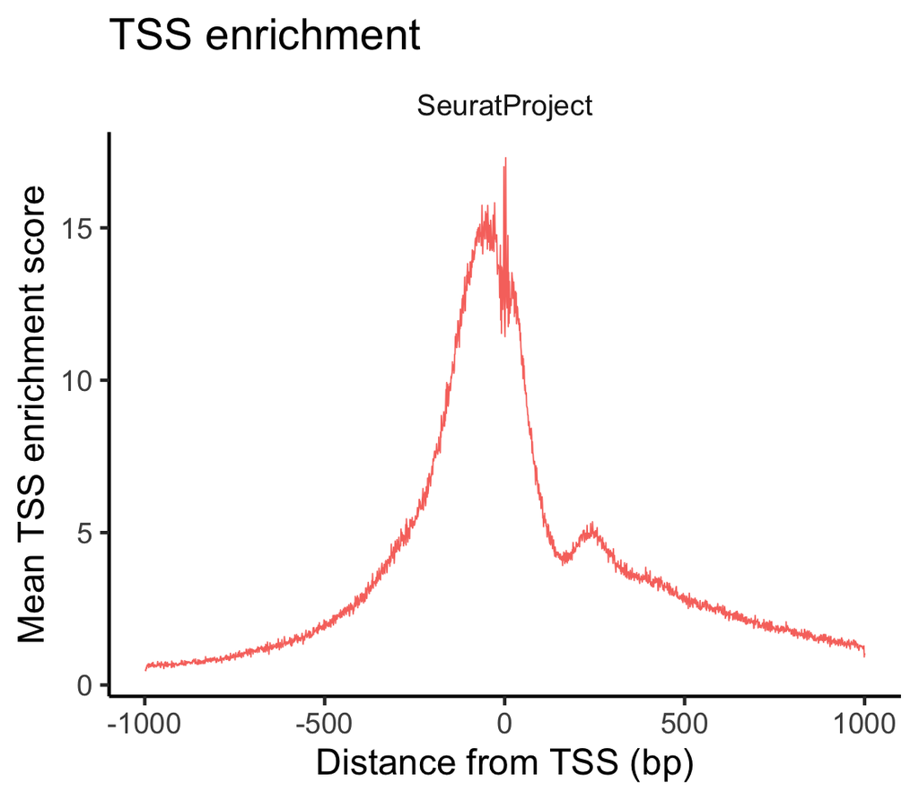

TSS enrichment profile

## Grabbing an Annotation

The first step to calculating TSS enrichment is loading in a reference gene annotation with the TSS regions. The gene ranges from which to specify TSS can be provided directly as a GTF file. Here though we grab the appropriate information from R package database *AnnotationHub*. In this case we will grab the ENSEMBL version of human gene annotation.

We must first use query to find the name of the Annotation for the genome version we want: EnsDb.Hsapiens.v98

```r
library(AnnotationHub)
ah <- AnnotationHub()
```

```r
query(ah, "EnsDb.Hsapiens.v98")
```

```
AnnotationHub with 1 record
# snapshotDate(): 2026-04-23
# names(): AH75011
# $dataprovider: Ensembl
# $species: Homo sapiens
# $rdataclass: EnsDb
# $rdatadateadded: 2019-05-02
# $title: Ensembl 98 EnsDb for Homo sapiens
# $description: Gene and protein annotations for Homo sapiens based on Ensem...
# $taxonomyid: 9606
# $genome: GRCh38
# $sourcetype: ensembl
# $sourceurl: http://www.ensembl.org
# $sourcesize: NA
# $tags: c("98", "AHEnsDbs", "Annotation", "EnsDb", "Ensembl", "Gene",
#   "Protein", "Transcript")
# retrieve record with 'object[["AH75011"]]'
```

## Grabbing an Annotation

Once we know the name of the annotation (AH75011), we can then use that to index it out from the database and convert it to a GRanges object.

```r
ensdb_v98 <- ah[["AH75011"]]
```

```r
annotations <- GetGRangesFromEnsDb(ensdb = ensdb_v98)
head(annotations)
```

```
GRanges object with 6 ranges and 5 metadata columns:
                  seqnames        ranges strand |           tx_id   gene_name
                     <Rle>     <IRanges>  <Rle> |     <character> <character>
  ENSE00001489430        X 276322-276394      + | ENST00000399012      PLCXD1
  ENSE00001536003        X 276324-276394      + | ENST00000484611      PLCXD1
  ENSE00002160563        X 276353-276394      + | ENST00000430923      PLCXD1
  ENSE00001750899        X 281055-281121      + | ENST00000445062      PLCXD1
  ENSE00001719251        X 281194-281256      + | ENST00000429181      PLCXD1
  ENSE00001489388        X 281381-281684      + | ENST00000381657      PLCXD1
                          gene_id   gene_biotype     type
                      <character>    <character> <factor>
  ENSE00001489430 ENSG00000182378 protein_coding     exon
  ENSE00001536003 ENSG00000182378 protein_coding     exon
  ENSE00002160563 ENSG00000182378 protein_coding     exon
  ENSE00001750899 ENSG00000182378 protein_coding     exon
  ENSE00001719251 ENSG00000182378 protein_coding     exon
  ENSE00001489388 ENSG00000182378 protein_coding     exon
  -------
  seqinfo: 25 sequences (1 circular) from GRCh38 genome
```

## Grabbing an Annotation

Next we need to amend the annotations to be using UCSC-style chromosomes as this is what Cell Ranger used. We can then add the annotation to Signac object.

```r
seqlevels(annotations) <- paste0('chr', seqlevels(annotations))
genome(annotations) <- "hg38"

Annotation(pbmc) <- annotations
```

## TSS enrichment distribution

We can first calculate the score, then plot it. The go-to plot for many QC metrics is a Violin plot so we can see the full distribution of the cells along the metric of choice.

```r
pbmc <- TSSEnrichment(object = pbmc)

VlnPlot(object = pbmc,
  features = c('TSS.enrichment'))
```

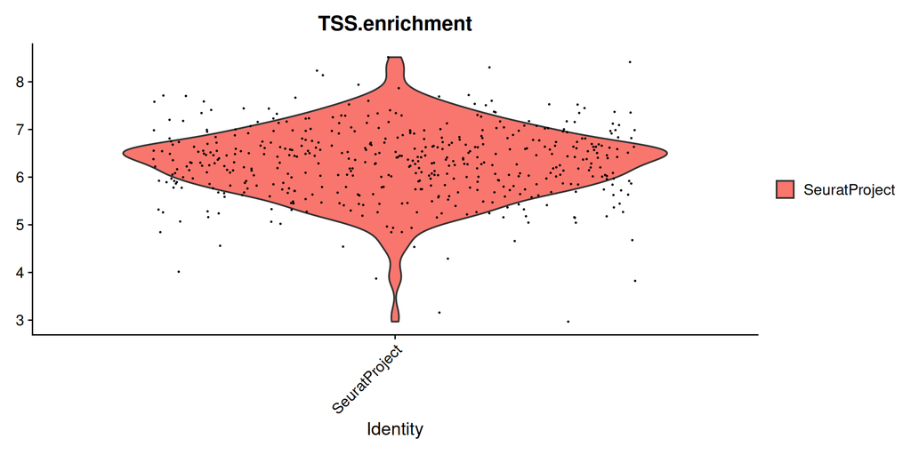

## TSS enrichment metaplot

If you want to also draw the metaplot itself you will have to recalculate the TSS enrichment. To save memory the TSSEnrichment function does not save an aggregated matrix of *ATAC reads x TSS position*. By changing the *fast* argument away from its default to FALSE, this matrix is stored and can then be used to generate the TSS metaplot. These can be nice to compare between samples.

```r
pbmc <- TSSEnrichment(object = pbmc, fast = F)

TSSPlot(pbmc)
```

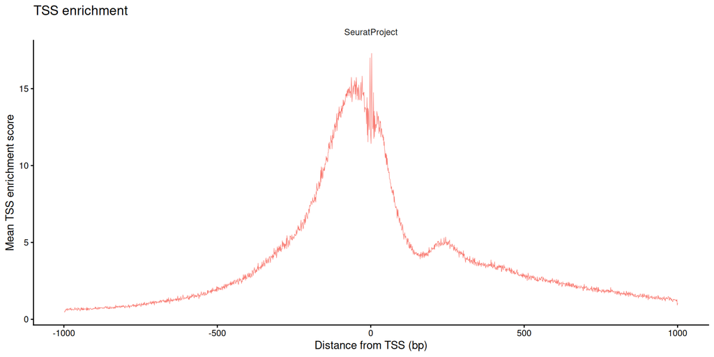

## TSS enrichment metaplot

It can also be useful to review potential thresholds by splitting the data using QC values like TSS enrichment. We can directly create a new metadata slot, then use that when we plot.

```r
pbmc$TSSE.group <- ifelse(pbmc$TSS.enrichment > 4, "High", "Low")

TSSPlot(pbmc,
        group.by = "TSSE.group")
```

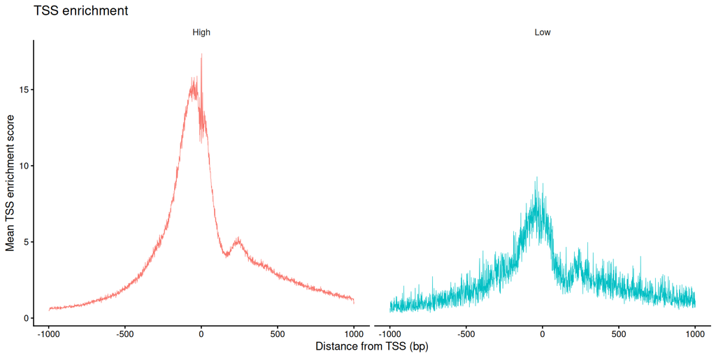

# Nucleosome Signal

## Fragment Size Periodicity

In good quality ATAC-seq libraries, fragment sizes show a characteristic **ladder pattern**. This fragment length periodicity happens because Tn5 can only cut between nucleosomes. The relative abundance of these groups is also indicative of sample quality.

- **< 147 bp** — nucleosome-free region (NFR); open chromatin
- **~200 bp** — mono-nucleosomal
- **~400 bp** — di-nucleosomal
- **~600 bp** — tri-nucleosomal

## Nucleosome Signal in Signac

Signac calculates a **nucleosome signal** score per cell: the ratio of mono-nucleosomal to sub-nucleosomal (NFR) fragment counts.

If a cell has a high nucleosome signal this means you’re fragments are larger and less digested.

## Nucleosome Signal in Signac

High values for nucleosome signal can indicate several QC problems: * Most of the time it is low tagmentation efficiency * Dying/damaged cells

```r
pbmc <- NucleosomeSignal(object = pbmc)

VlnPlot(pbmc, features = "nucleosome_signal")
```

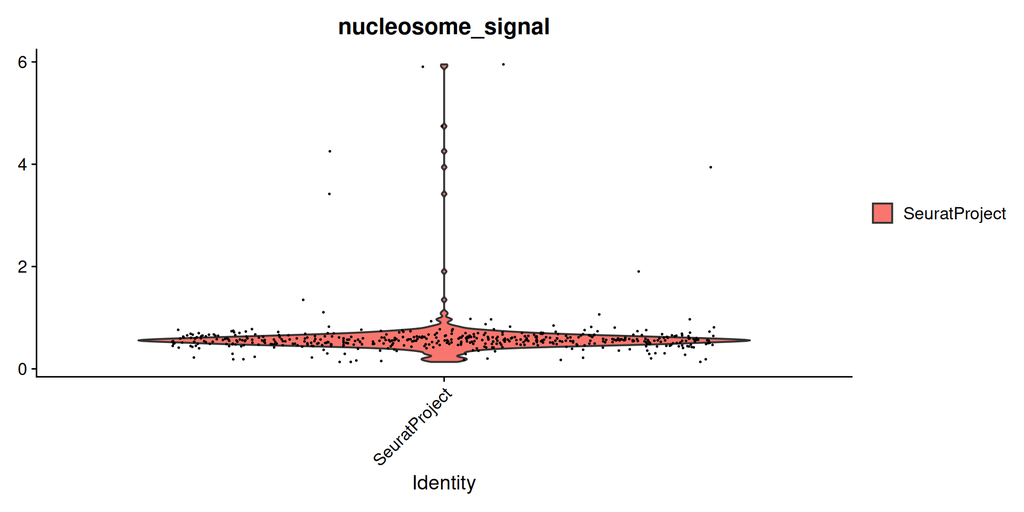

## Fragment ladder

We can also visualize the fragment ladder as a histogram through Signac using *FragmentHistogram*. If you can’t see any ladder you likely have a low quality/failed library.

```r
FragmentHistogram(
  object = pbmc
)
```

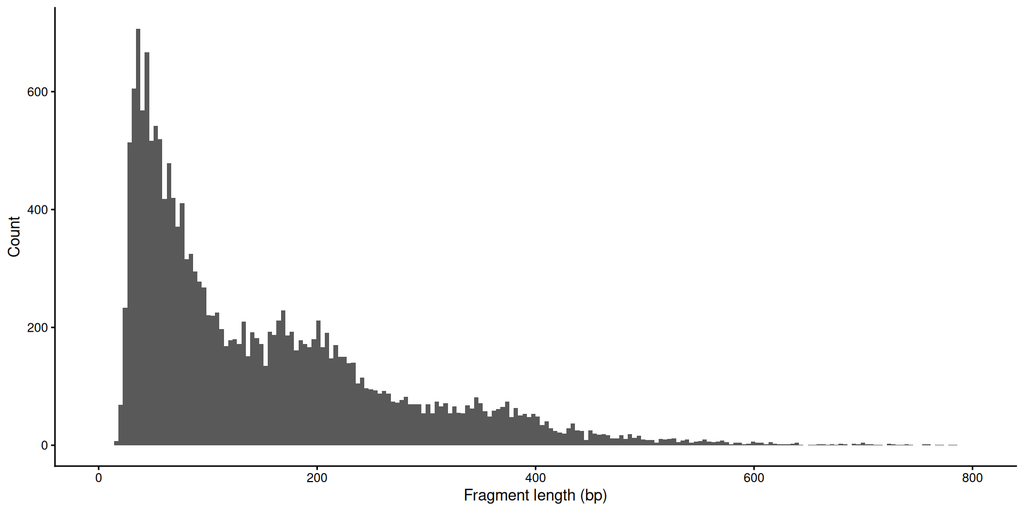

## Fragment ladder

As we did with TSSE we can split our plots up using our nucleosome signal.

```r
pbmc$nucleosome_group <- ifelse(pbmc$nucleosome_signal > 2,
                                 "NS > 2", "NS < 2")
FragmentHistogram(
  object   = pbmc,
  group.by = "nucleosome_group"
)
```

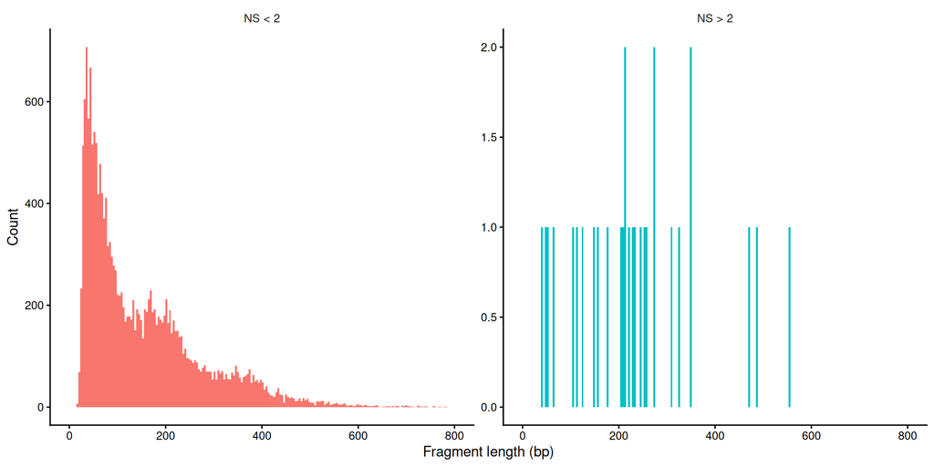

# Fraction of Reads in Peaks (FRiP)

## Fraction of Reads in Peaks (FRiP)

Cell Ranger has called peaks for us. **FRiP** measures the proportion of a cell’s fragments that overlap these called peaks. As with TSSE, a high proportion of reads in peaks indicates efficient ATAC. It also suggests that you have good peak calling.

- High FRiP → reads concentrated at accessible sites → good signal-to-noise
- Low FRiP → reads scattered across the genome → likely low-quality cell, ambient DNA or over-tagmentation.

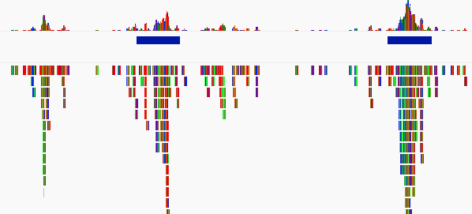

FRiP

## Fraction of Reads in Peaks (FRiP)

When you read Cell Ranger objects into Signac several metrics come for free. This includes:

1. passed_filters - Total number of high-quality, usable fragments that passed filtering for each cell
2. peak_region_fragments - Total number of fragments falling within the peaks called for that cell

We can easily calculate FRiP from this.

```r
pbmc$pct_reads_in_peaks <- pbmc$peak_region_fragments /
                            pbmc$passed_filters * 100
```

There is also a FRiP() function if you decide to recalculate peaks or use a non-10X technology.

## Fraction of Reads in Peaks (FRiP)

We can then visualize this again with VlnPlot.

```r
VlnPlot(pbmc, features = "pct_reads_in_peaks")
```

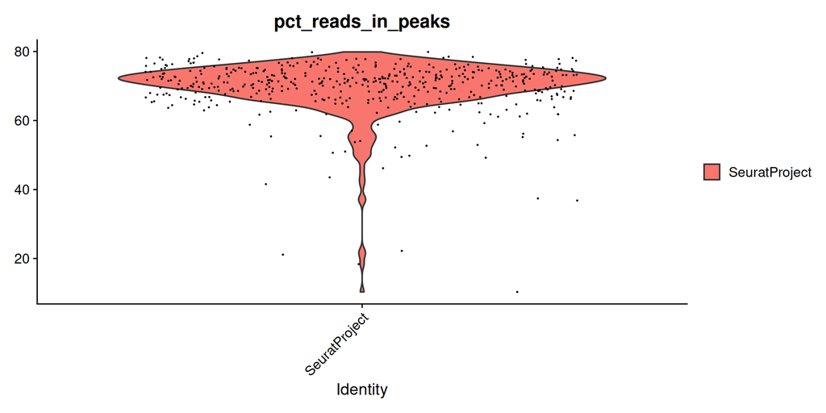

# Blacklist/Exclusion regions

## Blacklist/Exclusion regions

Blacklist/Exclusion regions are genomic intervals with consistently anomalous signal in NGS experiments — caused by repetitive elements, satellite DNA, and regions of poor mappability. These regions are specifically problematic because the references rarely contain a true representation of the repeats, as it can be difficult to resolve.

A high blacklist ratio often points to low-quality or misassigned barcodes

**Note**

Though these regions have traditionally been called blacklist regions, there is an increasing prevalence for these areas of the genome to be called exclusion regions or high-signal artifacts as it’s more inclusive and precise language. We are referring to both as many online resources still use the term blacklist and the field is still mid-transition.

## Blacklist/Exclusion regions

Here is an example for the Human Centromeric alpha satellite:

- Cells: ~0.5 million copies per genome.
- Reference (hg19): 3Mb of empty N’s per chromosome, with a few copies at each boundary.
- Result: Huge inflation of signal at these boundary regions across NGS technologies.

These regions are both manually and computationally curated by systematic review of 100s of different cell types. Some regions have 1000+ times the signal versus expected background.

## In this dataset

This is a region from this dataset. This is a small nuclear RNA gene that exists as multiple copies in tandem on the genome, but not in the reference.

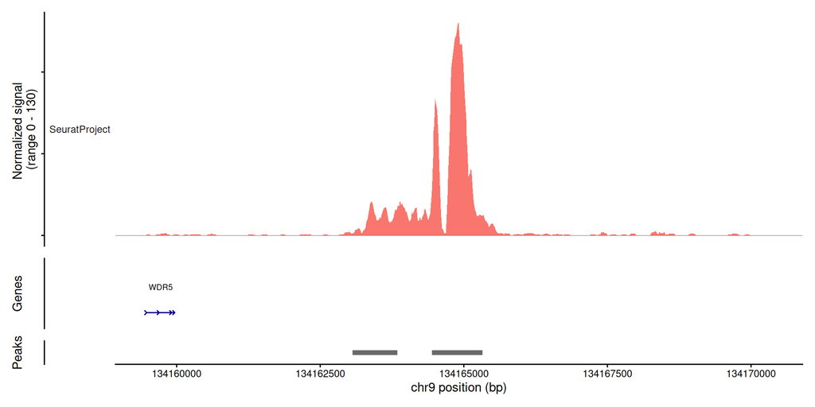

## Blacklist/Exclusion regions

Older versions of Cell Ranger used to report the blacklist fragments in *blacklist_region_fragments*. This is not the case anymore so you need to calculate it. The slot does still exists in the created Signac object, but it is empty.

A comprehensive list of artifactual regions are also available in the [excluderanges](https://www.bioconductor.org/packages/release/data/annotation/html/excluderanges.html) R package.

Several are also included in Signac. The PBMC dataset we are using was mapped to hg38, so lets look at *Signac::blacklist_hg38*.

## Blacklist/Exclusion regions

**hg38**

- 636 regions
- Median is 10kb
- Largest is >30Mb

```r
Signac::blacklist_hg38
```

```
DeprecatedGRanges object with 636 ranges and 1 metadata column:
        seqnames            ranges strand |             reason
           <Rle>         <IRanges>  <Rle> |        <character>
    [1]    chr10           0-45700      * |    Low Mappability
    [2]    chr10 38481300-38596500      * | High Signal Region
    [3]    chr10 38782600-38967900      * | High Signal Region
    [4]    chr10 39901300-41712900      * | High Signal Region
    [5]    chr10 41838900-42107300      * | High Signal Region
    ...      ...               ...    ... .                ...
  [632]     chrY   4343800-4345800      * | High Signal Region
  [633]     chrY 10246200-11041200      * | High Signal Region
  [634]     chrY 11072100-11335300      * | High Signal Region
  [635]     chrY 11486600-11757800      * | High Signal Region
  [636]     chrY 26637300-57227400      * | High Signal Region
  -------
  seqinfo: 24 sequences from an unspecified genome; no seqlengths
```

## Calculating Blacklist/Exclusion proportion

We can then calculate the fraction of reads in these exclusion ranges by doing the FractionCountsInRegion function. This can be used to also check any provided regions, so you can also use it to check know regions of interest as a positive control.

One thing to note is that this function is doing this in the context of the peaks, so you have low FRiP or poor peak calling in general this metric would then be off.

```r
pbmc$excl_prop <- FractionCountsInRegion(
  object = pbmc,
  assay = 'peaks',
  regions = blacklist_hg38
)
```

## Blacklist/Exclusion proportion

```r
VlnPlot(pbmc, features = "excl_prop")
```

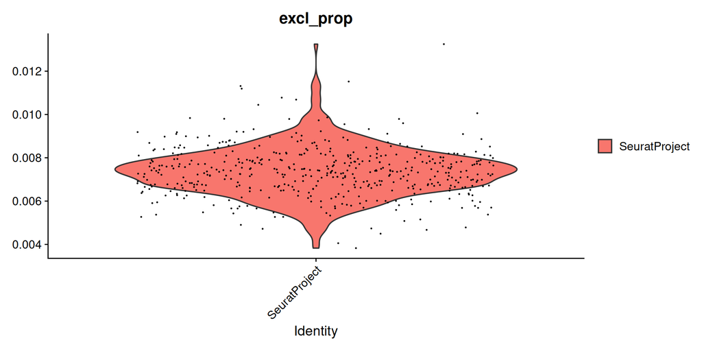

# Doublets

## Doublets

Doublets occur when multiple cells/nuclei are in the same droplet. The worst case scenario for this is that these they come from wildly different cell types, resulting in a heterotypic intermediate profile.

Doublets typically occur when a large number of cells are loaded or if there is inefficient disaggregation.

Often a simple filter of cells with high ca will remove most doublets. That said we can use specialist tools to help. Our preferred tool is **scDblFinder**.

## scDblFinder methods

scDblFinder has two methods that we can use:

1. scDblFinder
- Originally developed for RNAseq, but has settings good for ATAC-seq
- Simulates doublets using pairs of cells, and then tests if real cells are similar to simulated cells.
- Sensitive to heterotypic duplicates
2. AMULET
- ATAC-specific
- Counts genome positions and looks for anywhere with >2 counts
- Sensitive to heterotypic and homotypic duplicates

As both these methods use very different approaches they are seen as complementary and often both can be run.

## scDblFinder

scDblFinder is a Bioconductor package, so we have to coerce our Signac object into the Bioconductor specific SingleCellExperiment object type.

```r
library(scDblFinder)
library(SingleCellExperiment)
library(GenomicRanges)

sce <- as.SingleCellExperiment(pbmc, assay = "peaks")
```

## scDblFinder

Before we can run scDblFinder we must first set a seed. This is important for reproducibility, as the doublet simulation process is random.

We also use several ATAC-specific arguments:

- aggregateFeatures = TRUE - Relative to scRNA, scATAC has many more features, with each having lower signal. For ATAC we aggregate signal at many features (peaks) together.
- nfeatures = 25 - The feature are aggregated into meta-features. We can then choose how many meta-features to use.
- processing = “normFeatures” - As we have a low number of meta-features, we can stick to basic normalization without full dimension reduction.
- dbr = NULL - You can provide an expected doublet rate. For scATAC it is typically low, especially this kind of PBMC data.

```r
set.seed(42)
sce <- scDblFinder(
  sce,
  aggregateFeatures = TRUE,
  nfeatures         = 25,
  processing        = "normFeatures",
  dbr               = NULL
)
```

## AMULET

While standard scDblFinder works from the count matrix, AMULET utilizes the fragment files, as it looking genome wide for anywhere with >2 reads. As a result this can be a longer and memory-intensive process

First we will grab the path to the fragment file.

```r
frag_path <- GetFragmentData(Fragments(pbmc)[[1]], slot = "path")
```

## AMULET

We also want to mask any genome ranges that are considered problems because they have high chances of inappropriate mapping i.e. mitochondria, sex chromosomes, repeats and exclude ranges.

Most of these are easy to do/we already have loaded in. We just need to grab extra repeat information by getting the [RepeatMasker](https://github.com/Dfam-consortium/RepeatMasker/) for our genome. We can use AnnotationHub again.

```r
library(AnnotationHub)
ah <- AnnotationHub()

rm_q <- query(ah, c("RepeatMasker", "hg38"))
mcols(rm_q)[, c("title", "rdataclass", "sourceurl")]
```

```
DataFrame with 3 rows and 3 columns
                          title  rdataclass              sourceurl
                    <character> <character>            <character>
AH99003  UCSC RepeatMasker an..     GRanges https://functionalge..
AH107310 hg38.Reddy.wgEncodeD..     GRanges https://drive.google..
AH111333 UCSC RepeatMasker an..     GRanges https://functionalge..
```

```r
# Downloading the repeats is only needed to run AMULET, which the render loads
# from a checkpoint (see below), so it only runs when rebuilding checkpoints.
rmsk <- rm_q[[which(rm_q$rdataclass == "GRanges")[1]]]
```

## AMULET

Lets now create a combined set of exclusion ranges comprising of RepeatMasker, non-canonical chromosomes and the exclude ranges from ENCODE.

```r
plain <- function(gr) GRanges(as.character(seqnames(gr)), ranges(gr))

excl <- reduce(c(
  GRanges(c("chrM", "chrX", "chrY"), IRanges(1L, width = seqlengths(Annotation(pbmc))["chrX"])),
  plain(blacklist_hg38_unified),
  plain(rmsk)
))
```

## AMULET

Now lets run AMULET. If you run this you will see what we mean by much more heavy duty process. Even on this simple and small dataset it takes a few minutes. This is a lot longer then scDblFinder at <10s.

We pass `barcodes = colnames(pbmc)` so AMULET only scores our called cells. AMULET compares each cell’s number of high-overlap sites with the average across the barcodes it analyses. Including empty droplets and debris, which have few fragments, would lower that average and inflate doublet calls. Restricting to cells is also faster.

**Warning**

**We will not run this chunk in class.** AMULET takes around 10 minutes even on this small dataset. To follow along, load the pre-computed result instead: `amu <- readRDS("data/amulet_pbmc500.rds")`

```r
amu <- amulet(
  frag_path,
  barcodes         = colnames(pbmc),
  regionsToExclude = excl
)
```

## Adding doublet calls

Now that we have our doublet scoring we will want to add it back to our Signac object. During the AMULET calling the order can shift so first we will start by making sure they are ordered the same. Then we can just assign out the scores and classifications into the Signac.

```r
amu <- amu[colnames(pbmc), ]

pbmc$amulet.nAbove2 <- amu$nAbove2
pbmc$amulet.q <- amu$q.value
pbmc$amulet.class <- ifelse(amu$q.value<0.01, "Doublet", "Singlet")

pbmc$scDblFinder.score <- sce$scDblFinder.score
pbmc$scDblFinder.class <- sce$scDblFinder.class
```

## Reviewing doublets

You can see that there is quite different doublet calls between these two callers. scDblFinder is a lot more conservative.

A typical scATAC has varied doublet rates depending on how many cells were loaded (0.5 -10%). 500 cells is on the low end for loading, so we’re expecting 0.5% i.e. 2.5 doublets. By default scDblFinder is expecting 1%.

It seems like we have overcalling of doublets. Especially in AMULET.

```r
table(scDblFinder = pbmc$scDblFinder.class,
      amulet      = pbmc$amulet.class)
```

```
           amulet
scDblFinder Doublet Singlet
    singlet      87     381
    doublet       7       7
```

## Reviewing AMULET doublets

Overcalling is a known property of AMULET. Underlying the significance calling is an assumption that the mean depth is the same per cell, but in reality per cell sequencing depths in scATAC easily vary 5–10-fold.

As expected AMULET results correlates strongly with nCount.

```r
VlnPlot(pbmc, features = "nCount_peaks",
        group.by = "amulet.class", pt.size = 0.1)
```

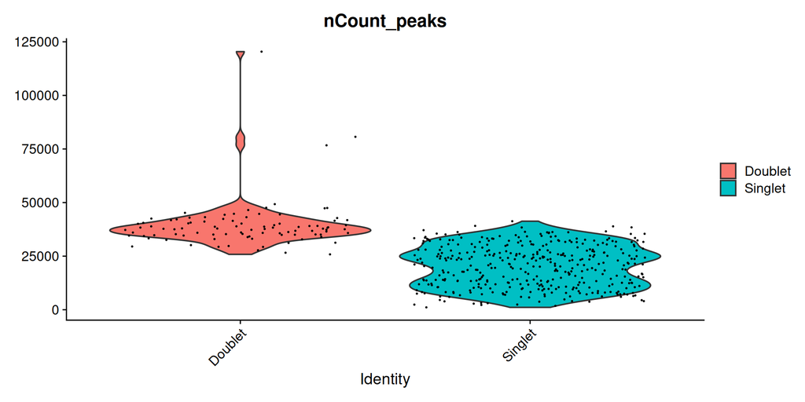

## Reviewing AMULET doublets

Though we have removed repeats we are running into an issue of more regions with >2 counts then expected. This becomes more of an issue when you have high depth in sequencing (like this dataset). Any minor repeats, CNVs, extrachromosomal DNA, polyploidy etc. that have not been filtered, start to gain prominence with deeper sequencing. If you know of these specifically in your samples you can diagnose and exclude them.

If *nAbove2* is ~5 or more AMULET will start to struggle. This suggests it would not be good for this dataset.

```r
VlnPlot(pbmc, features = "amulet.nAbove2",
  group.by = "amulet.class", pt.size = 0.1, log =T)
```

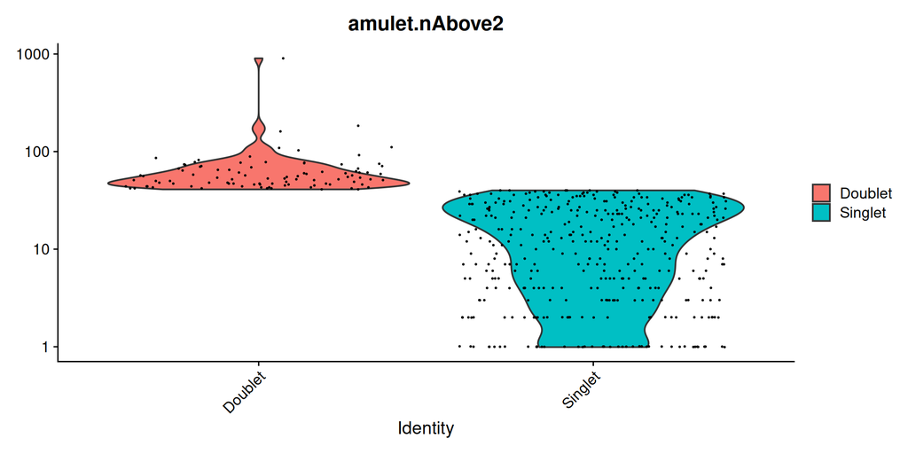

## Reviewing scDblFinder doublets

The relationship between nCounts and scDblFinder is much weaker, though they do still to correlate somewhat.

```r
VlnPlot(pbmc, features = "nCount_peaks",
        group.by = "scDblFinder.class", pt.size = 0.1)
```

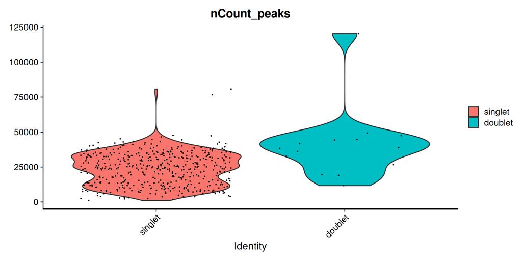

## Reviewing doublets

It is clear that at least AMULET doublet calls would not be a conservative filter and has potential issues for this dataset. We need to always keep an eye on the base assumptions of our tools and how it relates to our data.

Using a different depth-aware statistical test would likely improve AMULET i.e. replace AMULETS poisson with a negative binomial.

It is also possible to combine pvalues so that you can filter based on the pvalues of both doublet using a tool like [metapod](https://bioconductor.org/packages/release/bioc/html/metapod.html).

# Filtering cells

## QC in scATAC-seq is iterative

Unlike RNA-seq where QC thresholds are relatively standard, scATAC-seq QC is more sensitive to the tissue, protocol, and sequencing depth. The iterative process of revisiting QC is even more important as a result.

We need to: * Inspect the distributions * Apply conservative thresholds initially * **Revisit QC after clustering** — low-quality cells often form isolated clusters with poor marker accessibility. * Repeat

## Visualizing all QC metrics together

By looking at all these metrics together we can get a one stop summary plot that gives you a sense how many outliers you have.

```r
library(ggplot2)
VlnPlot(
  object   = pbmc,
  features = c(
    "nCount_peaks",
    "TSS.enrichment",
    "excl_prop",
    "nucleosome_signal",
    "pct_reads_in_peaks"
  ),
  pt.size = 0.1,
  ncol    = 5
) & theme(plot.title = element_text(size = 8))
```

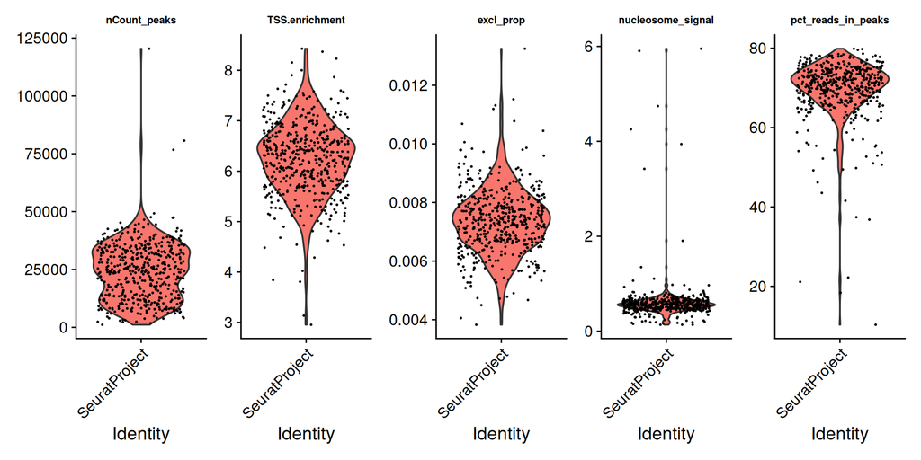

## Density Scatter for Joint QC

We can also use multiple metrics at once to review the data. Density scatters are a good way to do this. These also add in suggested thresholds. Often we compare nCount_peaks to TSS.enrichment and FRiP, but you can compare along any metrics.

```r
DensityScatter(
  object     = pbmc,
  x          = "nCount_peaks",
  y          = "TSS.enrichment",
  log_x      = TRUE,
  quantiles  = TRUE
)
```

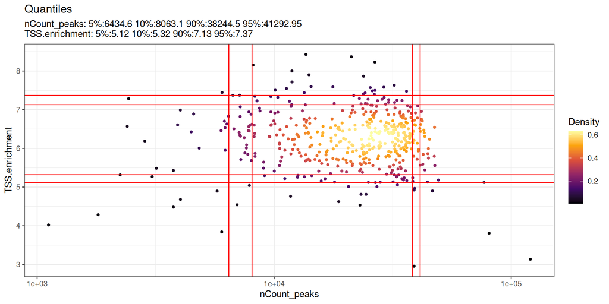

## Density Scatter for Joint QC

Look for a main cloud of high-quality cells and isolated low-quality populations below/above potential enrichment thresholds.

```r
DensityScatter(
  object     = pbmc,
  x          = "nCount_peaks",
  y          = "pct_reads_in_peaks",
  log_x      = TRUE,
  quantiles  = TRUE
)
```

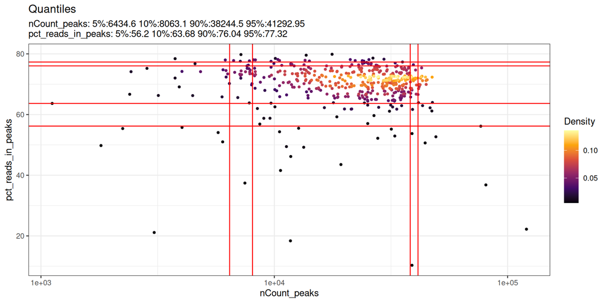

## Typical Thresholds

Lets look at some other examples of PBMC data. This is from a paper comparing different sequencing technologies.

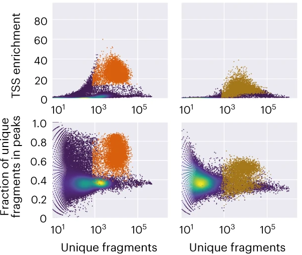

[(De Rop *et al*, 2023)](https://www.nature.com/articles/s41587-023-01881-x?st_source=ai_overview)

## Choosing Sensible Thresholds

Let’s remember:

1. Apply conservative context-specific thresholds initially
2. UMAP and Cluster
3. Double-check QC metrics on UMAP to see if anything is sticking out
4. Update filters and go back to 2, until there are no remaining QC concerns.

## Typical Thresholds

**Common starting points for 10x PBMC (hg38):**

| Metric | Minimum | Maximum |
| --- | --- | --- |
| nCount_peaks | 1,000 | 30,000 |
| TSS.enrichment | 2 | — |
| nucleosome_signal | — | 4 |
| pct_reads_in_peaks | 15 | — |
| blacklist_ratio | — | 0.05 |

## Threshold Ranges

PBMC datasets are typically good data, so thresholds end up more stringent. The experimental context impacts chosen thresholds a lot.

- *High quality data:* Fresh blood, cell lines, deep sequencing.
- *Low quality data:* Frozen, postmortem, FFPE, fibrous or fatty tissue, multiomic, shallow sequencing.

Lets walk through some typical ranges.

## Fragments/nCounts

- Minimum fragments
  - High quality: 3k–10k
  - Low quality: 1k–1.5k

This mostly depends on sequencing depth and library complexity - samples from FFPE are much lower for this, so need more lenient thresholds.

- Maximum fragments
  - Top 1–2%

This is variable and more about skimming of the top based on the distribution, rather then a fixed value. You can also use [MAD to determine outliers](https://bioconductor.org/books/3.13/OSCA.advanced/quality-control-redux.html). The right value grows with sequencing depth and cells loaded. It is useful to pair this with doublet detection to remove these high count cells.

## TSS enrichment

- High quality: 4-8
- Low quality: 1-2

**Warning**

Values can’t be compared between tools. Signac, ArchR, ENCODE etc calculate the score slightly differently.

## Nucleosome signal

- High quality: < 2
- Low quality: up to 4

Nucleosome signal is the ratio of mono-nucleosome fragments to nucleosome-free fragments, so higher values mean less of the open, nucleosome-free signal ATAC is designed to capture. It is sensitive to nuclei integrity and the Tn5-to-nuclei ratio, so degraded or under-tagmented samples sit higher.

**Tip**

Rather than relying on a fixed cut-off, compare the fragment size histograms of cells above and below your threshold with *FragmentHistogram*. Cells with a weak nucleosome-free peak, or no clear ladder, are the ones to remove.

## FRiP

- High quality: > 40%
- Low quality: 15–20%

FRiP is relatively sensitive to method as it’s a very direct readout of ATAC efficiency.

**Warning**

In a tissue with rare cell types, it is often necessary to re-call peaks per cluster before filtering with this cutoff.

## Blacklist/Exclude Ranges

- High quality: < 0.01
- Low quality: ≤ 0.05

**Warning**

Blacklist proportion is calculated in the context of peaks, so a low-FRiP sample automatically has a higher ratio. That’s why depending on context you may need a looser value.

## Sensible thresholds

- We have given rough guidelines for thresholds
- Context matters a lot though
- Review your data distributions and make conservative choices. You can always come back and filter more.

## Reasonable cut-offs for this data

Looking at this data what are we thinking?

| Metric | Minimum | Maximum |
| --- | --- | --- |
| nCount_peaks | 5,000 | 60,000 |
| TSS.enrichment | 4 | — |
| nucleosome_signal | — | 2 |
| pct_reads_in_peaks | 40 | — |
| blacklist_ratio | — | - |

We will also keep potential doublets for now. Often the Max nCount is sufficient to remove most doublets. But we have that calculated so we can keep an eye on it.

## Filtering in action

- Prefilter object

```r
pbmc
```

```
An object of class Seurat
61638 features across 482 samples within 1 assay
Active assay: peaks (61638 features, 0 variable features)
 2 layers present: counts, data
```

```r
pbmc <- subset(
  x      = pbmc,
  subset = nCount_peaks > 5000 &
           nCount_peaks < 60000 &
           TSS.enrichment > 4 &
           nucleosome_signal < 2 &
           pct_reads_in_peaks > 40
)
```

- Postfilter object

```r
pbmc
```

```
An object of class Seurat
61638 features across 458 samples within 1 assay
Active assay: peaks (61638 features, 0 variable features)
 2 layers present: counts, data
```

## Signac V2 - A quick aside

We have been using Signac version 1.17.1 or less. There is currently a beta for a major update for Signac to [Signac V2](https://stuartlab.org/signac2/). The general principles for importing the ATAC object and making the QC decisions we have talked about are the same.

That said they have rebuilt the internals to make it scale better for large datasets. This means it is likely current Signac objects will have to be converted into the new format to be able to be used with V2. They also have simplified the QC from multiple different steps to just a single function.

```r
ATACqc(pbmc)
```

Similarly is you want to use ArchR or snapATAC2 you will use the same approach but just different functions specific to those packages.

# Normalization with TF-IDF

## Why Not Just Log-Normalize?

In scRNA-seq, log-normalization corrects for sequencing depth.

For scATAC-seq this is **insufficient** because:

- Peaks are **binary-ish** — a peak is either accessible (~1) or not (~0) per cell
- Signal is **extremely sparse** — most peaks have 0 counts
- A simple log-normalization treats all peaks equally regardless of their overall accessibility across cells

**Important**

We need a method that down-weights common peaks and up-weights rare, informative ones

This is what TF-IDF does.

## TF-IDF: The Concept

**TF-IDF** (term frequency–inverse document frequency) is borrowed from text mining and information retrieval. The method is used to find how important a word is, to for a single document, in the context of a collection of documents.

In scATAC it is retooled to find how important a peak is to a given cell in context of a collection of cells.

- Part 1 - Normalizing for per-cell sequencing depth (TF)
- Part 2 - Up-weighting rarer, more informative peaks (IDF)

$$\text{TF-IDF}_{ij} = \text{TF}_{ij} \times \log\left(1 + \frac{N}{n_i}\right)$$

Where $N$ = total cells, $n_i$ = cells in which peak $i$ is accessible.

## More then simple normalization?

Yes. We already start to focus our attention on the biologically relevant peaks. Why do this for ATAC?

- Common peaks carry no cell-type information. A peak open in 90% of cells can’t distinguish T cells from B cells. Without IDF, these frequently detected peaks dominate the variance and therefore the dimensionality reduction.
- The data is sparse and almost binary. Each locus has at most 2 copies per nucleus, so most entries are 0 and the rest are 1 or 2. scRNA-seq log-normalization works on the size of counts, but there’s barely any size information here. What informs is which peaks a cell has, and IDF weights that.
- TF-IDF feeds directly into singular value decomposition (SVD), the dimension reduction technique used in scATAC. Together this approach is Latent Semantic Indexing (LSI), a technique also from text mining [Cusanovich et al, 2019](https://pmc.ncbi.nlm.nih.gov/articles/PMC6158300/).

## Running TD-IDF in Signac

```r
pbmc <- RunTFIDF(pbmc)

pbmc[["peaks"]]@data[1:5, 1:5]
```

```
5 x 5 sparse Matrix of class "dgCMatrix"
                   AAACTGCAGACTCGGA-1 AAAGATGCACCTATTT-1 AAAGATGCAGATACAA-1
chr1-629503-630399                  .          .                  .
chr1-778284-779205                  .          0.3036561          0.2838988
chr1-816914-817800                  .          .                  .
chr1-827058-827951                  .          .                  .
chr1-869449-870355                  .          .                  0.6055013
                   AAAGGGCTCGCTCTAC-1 AAATGAGAGTCCCGCA-1
chr1-629503-630399          .                   .
chr1-778284-779205          0.6650193           .
chr1-816914-817800          .                   .
chr1-827058-827951          0.4758799           .
chr1-869449-870355          0.6717577           1.467326
```

**Note**

The normalized values are stored in the `data` slot. The raw counts remain in the `counts` slot and are needed for differential accessibility testing later.

# Feature Selection

## Why Select Features?

With ~100,000 peaks, working with the full matrix is computationally expensive and statistically noisy.

Many peaks are accessible in only 1–2 cells (likely noise) or in almost every cell (uninformative for distinguishing cell types).

We want peaks with **intermediate frequency** — those that vary meaningfully between cells.

We are upweighting rare peaks with TD-IDF, but to prevent noise creeping through we also want to filter out the bottom peaks. We do this calculation in parallel with TF-IDF before we tackle the next steps of dimension reduction and clustering.

## FindTopFeatures

To select features with Signac we run FindTopFeatures. This is equivalent to FindVariableFeatures in Seurat. As we also have run TD-IDF we do not need the most variable as we will be upweighting interesting peaks. So instead we can just find the top features.

In this case we will filter to the peaks in the top 95th percentile of total normalized counts. You can also filter on a specific value i.e min.cutoff = 20 (remember when we run the import we already filtered out the low end with min.cells = 10).

```r
pbmc <- FindTopFeatures(pbmc, min.cutoff = "q5")

length(VariableFeatures(pbmc))
```

```
[1] 59362
```

```r
head(VariableFeatures(pbmc))
```

```
[1] "chr8-8227858-8228742"    "chr1-30717964-30718898"
[3] "chr9-93095451-93096354"  "chr19-54136923-54137856"
[5] "chr1-15524228-15525249"  "chr11-59615621-59616569"
```

## FindTopFeatures filter

In the Signac vignette they actually include all features (q0) to process the PBMC dataset, but said it is robust with only 25% of peaks (q75).

Setting the threshold is a balance and dataset dependent.

If you keep too much there will be more noise and slower. If you filter too much rare, cell-type specific peaks are lost and the resulting clusters would merge.

## FindTopFeatures filter

A good place to start is with Signac defaults (q5). But if you are not seeing good cluster definition at latter steps, or rare types are missing then you may need to optimize the filter further.

If you want to change the cutoffs, have a quick check of the counts distribution.

```r
peak_counts <- rowSums(GetAssayData(pbmc, assay = "peaks", layer = "counts"))
quantile(peak_counts, c(0.05, 0.25, 0.5, 0.75))
```

```
 5% 25% 50% 75%
 22  37  67 173
```

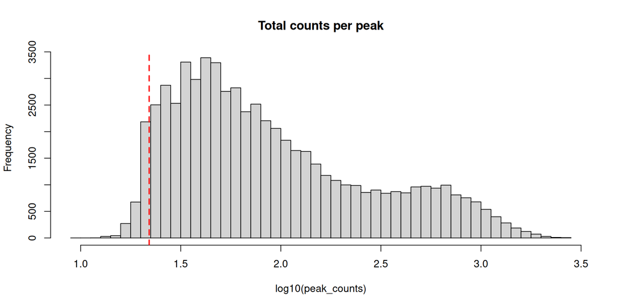

```r
hist(log10(peak_counts), breaks = 50, main = "Total counts per peak")
abline(v = log10(22), col = "red", lty = 2, lwd = 2)
```

## FindTopFeatures filter

You can also check cluster stability. We will be getting into clustering next session, but we will quickly review this idea.

By running clustering with multiple different feature cutoffs you can assess similarity of clusters at each cutoff level.

1. Run LSI and clustering with different feature selection thresholds.
2. Directly check overlap in cluster identities. Look for missing small clusters.
3. Do statistical testing of cluster stability using packages like [bluster](https://bioconductor.org/packages//release/bioc/vignettes/bluster/inst/doc/diagnostics.html)

# Recalling Peaks

## Re-calling peaks and consensus peak sets

We are using the peaks Cell Ranger called on all cells pooled together. These can miss peaks that are only open in rare cell types, and they do not match between samples.

Once we have clusters we can re-call peaks for each group with MACS and build a consensus peak set. We cover this in Session 3, after dimensionality reduction and clustering.

## Time for an exercise!

Exercise on QC and preprocessing can be found here

## Answers to exercise.

Answers can be found here